# Murine positive selection

```r
knitr::opts_chunk$set(echo = TRUE, warning = FALSE, message = FALSE)

library(ggplot2)
library(cowplot)
library(ggbeeswarm)
library(dplyr)
#library(kableExtra)
library(tidyr)
library(ggtree)
library(phytools)
library(phangorn)
library(reshape2)
library(ggExtra)
library(ggrepel)
#library(vroom)
library(ggdist)
#library(stringr)
library(ggsignif)
source("../lib/design.r")
source("../lib/get_tree_info.r")
```

< Back to summary

```r
tree_type = "astral"
save_tree_fig = F

cat(tree_type, " tree\n")
```

```
## astral  tree
```

```r
cat("188 species targeted capture to mouse exons assembled with SPADES.\n")
```

```
## 188 species targeted capture to mouse exons assembled with SPADES.
```

```r
cat("Pared to 109 species based on paring algorithm")
```

```
## Pared to 109 species based on paring algorithm
```

```r
cat("11,775 coding loci aligned with exonerate+mafft\n")
```

```
## 11,775 coding loci aligned with exonerate+mafft
```

```r
cat("Gene trees inferred with IQtree.\n")
```

```
## Gene trees inferred with IQtree.
```

```r
if(tree_type == "astral"){
  cat("Species tree inferred with ASTRAL.\n")
  cat("Branch lengths estimated by ASTRAL.\n")
  tree_file = "../../data/trees/paring/min-spec-paring-astral-exempt-2/iter-8-pared.tre"
  gene_ps_file = "../../data/ps/full-coding-absrel-pared.csv"
  branch_ps_file = "../../data/ps/full-coding-absrel-pared-branch-ps.csv"
  site_ps_file = "../../data/ps/full-coding-fel-pared.csv"
  morpho_branch_ps_file = "../../data/ps/full-coding-absrel-pared-branch-ps-morphofacial.csv"
  col_file = "../../data/trees/paring/astral-pared-2-colonization-branches.txt"
  morpho_file = "../../data/trees/astral-pared-morpho-ou-shift-branches.txt"
  morpho_genes_file = "../../data/datasets/subset_morphofacial_genes.txt"
  arid_genes_file = "../../data/datasets/arid-genes-giorello-2018-pid.txt"
  exclude_branches = c("Lophiomys_imhausi_UM5152", "Lophuromys_woosnami_LSUMZ37793", "<1>", "<108>", "<107>")
  xmax = 22
}else if(tree_type == "concat"){
  cat("Species tree inferred by concatenation of all loci with IQtree.\n")
  tree_file = "../../data/trees/full_coding_iqtree_concat.cf.rooted.tree"
  gene_ps_file = ""
  branch_ps_file = ""
  site_ps_file = ""
  col_file = ""
  exclude_branches = c("Lophiomys_imhausi_UM5152", "Lophuromys_woosnami_LSUMZ37793", "<1>", "<187>", "<186>")
  xmax = 0.125
}
```

```
## Species tree inferred with ASTRAL.
## Branch lengths estimated by ASTRAL.
```

```r
tree = read.tree(tree_file)
tree_to_df_list = treeToDF(tree)
tree_info = tree_to_df_list[["info"]]

if(tree_type == "astral"){
  tree_info = tree_info %>% separate(label, c("tp", "gcf"), sep=">_", remove=F)

  for(i in 1:nrow(tree_info)){
    if(tree_info[i,]$node.type == "internal"){
      if(substring(tree_info[i,]$tp, nchar(tree_info[i,]$tp)) != ">"){
        tree_info[i,]$tp = paste0(tree_info[i,]$tp, ">")
      }
    }

  }

  tree_info$astral[tree_info$node.type=="tip"] = NA
  tree_info$astral = as.numeric(tree_info$astral)
  tree_info$gcf = as.numeric(tree_info$gcf)
}else if(tree_type == "concat"){
  tree_info = tree_info %>% separate(label, c("tp", "bootstrap"), sep="/", remove=F)
  tree_info$bootstrap[tree_info$node.type=="tip"] = NA
  tree_info$bootstrap = as.numeric(tree_info$bootstrap)
  tree_info$gcf = as.numeric(tree_info$gcf)
  tree_info$scf = as.numeric(tree_info$scf)
}
```

```r
col_branches = read.csv(col_file, header=F)
names(col_branches) = c("tp", "region")

tree_info$col.branch = "Other"

tree_info$col.branch[tree_info$tp %in% col_branches$tp] = "Colonization"

#tree_info$col.desc.branch = "N"

for(i in 1:nrow(tree_info)){
  if(tree_info[i,]$node.type == "internal" && tree_info[i,]$col.branch == "Colonization"){
    cur_desc = getDescendants(tree, tree_info[i,]$node)
    tree_info$col.branch[tree_info$node==cur_desc[1]] = "Descendant"
    tree_info$col.branch[tree_info$node==cur_desc[2]] = "Descendant"
  }
}
```

# 1 Positive selection by gene (all genes)

```r
ps_genes = read.csv(gene_ps_file, header=T, comment.char="#")

#ps_branches = subset(ps_branches, !(tp %in% exclude_branches) )
```

(aBSREL)[http://www.hyphy.org/methods/selection-methods/#absrel] was run on all genes. aBSREL optimizes the number of rate categories per branch and then runs both a free-rate model and a model where it restricts the max rate to be 1 (no positive selection). It compares theses models with a likelihood ratio test and computes a p-value using a mixture of chi-squared distributions. All branches are tested, and aBSREL corrects the p-values for multiple testing within a gene using the Holm-Bonferroni method. After correcting p-values, branches are said to have evidence for positive selection if p < 0.05.

## 1.1 Percent of branches with significant p-value per gene

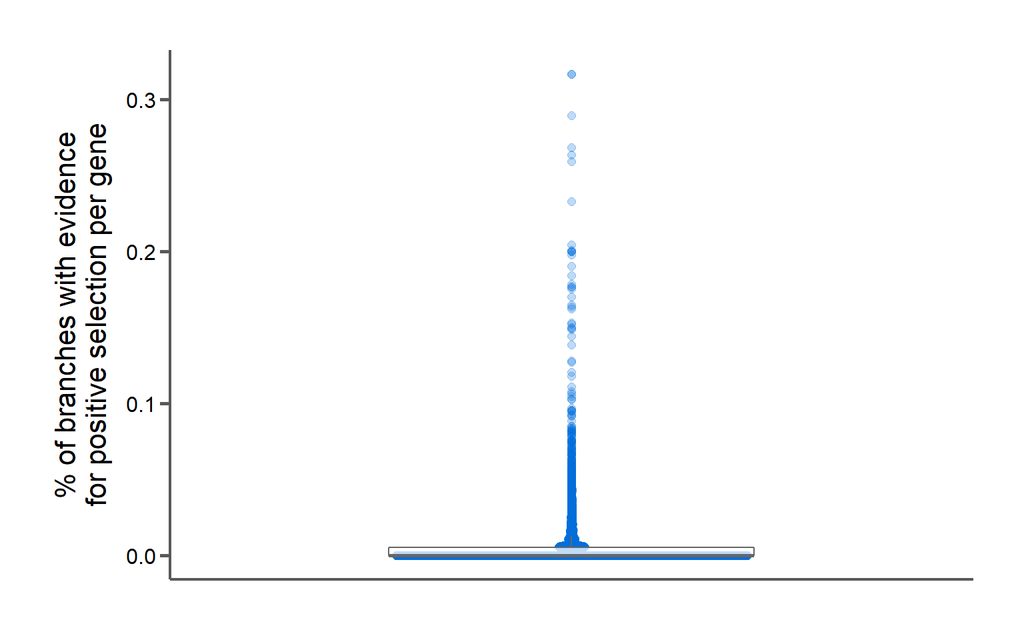

```r
ps_genes$perc.br.ps = ps_genes$num.branches.pval.less.than.alpha / ps_genes$num.branches

gene_p = ggplot(ps_genes, aes(x=1, y=perc.br.ps)) +
  geom_quasirandom(size=2, width=0.25, alpha=0.25, color=corecol(numcol=1, offset=2)) +
  geom_boxplot(outlier.shape=NA, alpha=0.75, width=0.5, color="#666666", width=0.25) +
  scale_x_continuous(limits=c(0.5,1.5)) +
  xlab("") +
  ylab("% of branches with evidence\nfor positive selection per gene") +
  bartheme() +
  theme(axis.title.x=element_blank(),
        axis.text.x=element_blank(),
        axis.ticks.x=element_blank())
print(gene_p)
```

# 2 Positive selection by branch (all genes)

```r
ps_branches = read.csv(branch_ps_file, header=T, comment.char="#")
names(ps_branches)[1] = "tp"
cols_to_na = names(ps_branches)[5:11]

for(col in cols_to_na){
  ps_branches[ps_branches$tp %in% exclude_branches,][[col]] = NA
}
# This loop changes all the counts for the branches descending from the root and the outgroup to NA to exclude them

ps_branches$perc.ps.genes = ps_branches$num.ps.genes / (ps_branches$num.genes.full + ps_branches$num.genes.partial)
```

## 2.1 Species tree branch presence/absence per gene

Following the [same procedure as before](https://goodest-goodlab.github.io/murinae-seq/trees-astral.html#average-rates-per-branch-with-basic-model-fit-mg94-local), we count multi-nucleotdie substitutions per species tree branch only in genes that contain that branch (full clade or partial clade).

NOTE: These distributions are for the PARED tree.

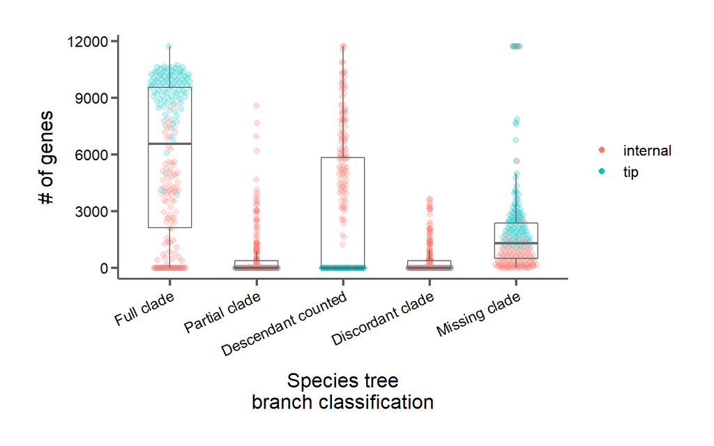

```r
#anc_info = subset(anc_info_w_root, node.type != "root")

full_clade = select(ps_branches, clade, node.type, num.genes.full)
full_clade$label = "Full clade"
names(full_clade)[3] = "num.genes"

partial_clade = select(ps_branches, clade, node.type, num.genes.partial)
partial_clade$label = "Partial clade"
names(partial_clade)[3] = "num.genes"

descendant_counted = select(ps_branches, clade, node.type, num.genes.descendant.counted)
descendant_counted$label = "Descendant counted"
names(descendant_counted)[3] = "num.genes"

discordant_clade = select(ps_branches, clade, node.type, num.genes.discordant)
discordant_clade$label = "Discordant clade"
names(discordant_clade)[3] = "num.genes"

no_clade = select(ps_branches, clade, node.type, num.genes.missing)
no_clade$label = "Missing clade"
names(no_clade)[3] = "num.genes"

clade_counts = rbind(full_clade, partial_clade, descendant_counted, discordant_clade, no_clade)
# Convert branch categories to long format

clade_counts$label = factor(clade_counts$label, levels=c("Full clade", "Partial clade", "Descendant counted", "Discordant clade", "Missing clade"))

branch_counts = ggplot(clade_counts, aes(x=label, y=num.genes, group=label, color=node.type)) +
  geom_quasirandom(size=2, width=0.25, alpha=0.25) +
  geom_boxplot(outlier.shape=NA, alpha=0.15, width=0.5, color="#666666") +
  ylab("# of genes") +
  xlab("Species tree\nbranch classification") +
  bartheme() +
  theme(axis.text.x = element_text(angle=25, hjust=1)) +
  guides(colour=guide_legend(override.aes=list(alpha=1)))
print(branch_counts)
```

```r
uniq_info_cols = names(ps_branches)[!(names(ps_branches) %in% names(tree_info))]
# # Get non common names

uniq_info_cols = c(uniq_info_cols, "tp") # appending key parameter
# Get a list of columns from the tree_info df to join to the tree rates df

tree_info = tree_info %>% left_join((ps_branches %>% select(uniq_info_cols)), by="tp")
# Select the columns from tree_info and join to tree_rates, merging by clade
# https://stackoverflow.com/a/61628157

tree_info = tree_info[order(tree_info$node), ]
# Re-order the rows by the R node
```

## 2.2 Tree with colonization branches labeled

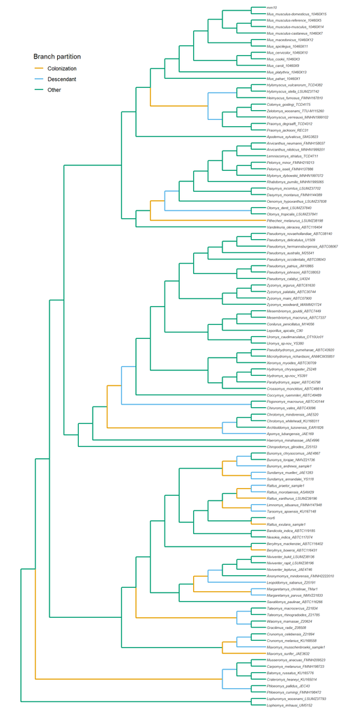

```r
h = corecol(numcol=1, pal="wilke", offset=3)
l = corecol(numcol=1, offset=3)
# Colors

col_tree = ggtree(tree, size=0.8, ladderize=F, aes(color=tree_info$col.branch)) +
  scale_color_manual(name='Branch partition', values=corecol(pal="wilke", numcol=3)) +
  xlim(0, xmax) +
  geom_tiplab(color="#333333", fontface='italic', size=2) +
  theme(legend.position=c(0.15,0.9))
print(col_tree)
```

```r
if(save_tree_fig){
  gcf_tree = gcf_tree + geom_text(aes(x=branch, label=ifelse(tree_info$node.type=="internal",as.character(node), ''), label.size=NA, fill="transparent"), size=2, vjust=-0.2)
  tree_outfile = paste("../../data/trees/", tree_type, "-gcf-tree-PARED-gcf50.pdf", sep="")
  ggsave(tree_outfile, gcf_tree, width=8, height=16, unit="in")
}
# Colonization branch tree
```

## 2.3 Branches under positive selection by colonization partition

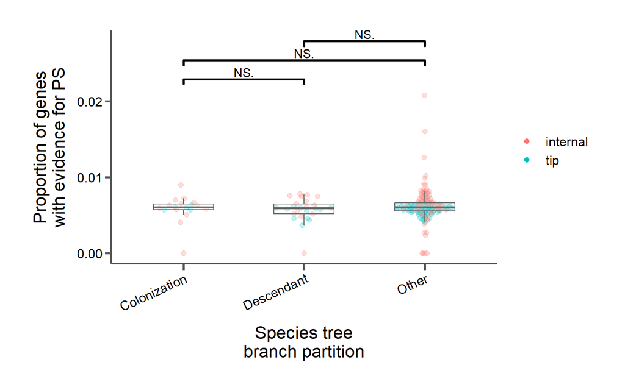

```r
col_ps = subset(select(tree_info, clade, node.type, col.branch, perc.ps.genes), col.branch == "Colonization")
col_ps$label = "Colonization"
#names(full_clade)[3] = "num.genes"

desc_ps = subset(select(tree_info, clade, node.type, col.branch, perc.ps.genes), col.branch == "Descendant")
desc_ps$label = "Descendant"

other_ps = subset(select(tree_info, clade, node.type, col.branch, perc.ps.genes), col.branch == "Other")
other_ps$label = "Other"

ps_counts = rbind(col_ps, desc_ps, other_ps)
# Convert branch categories to long format

ps_counts$label = factor(ps_counts$label, levels=c("Colonization", "Descendant", "Other"))

x_comps = list(c("Colonization", "Descendant"), c("Colonization", "Other"), c("Descendant", "Other"))

branch_ps_counts = ggplot(ps_counts, aes(x=label, y=perc.ps.genes, group=label, color=node.type)) +
  geom_quasirandom(size=2, width=0.25, alpha=0.25) +
  geom_boxplot(outlier.shape=NA, alpha=0.15, width=0.5, color="#666666") +
  geom_signif(comparisons=x_comps, map_signif_level=TRUE, textsize=4, size=1, step_increase=0.12, margin_top=0.1) +
  ylab("Proportion of genes\nwith evidence for PS") +
  xlab("Species tree\nbranch partition") +
  bartheme() +
  theme(axis.text.x = element_text(angle=25, hjust=1)) +
  guides(colour=guide_legend(override.aes=list(alpha=1)))
print(branch_ps_counts)
```

# 3 Positive selection by branch (1072 morphofacial genes)

```r
ps_branches_mf = read.csv(morpho_branch_ps_file, header=T, comment.char="#")
names(ps_branches_mf)[1] = "tp"
cols_to_na = names(ps_branches_mf)[5:11]

for(col in cols_to_na){
  ps_branches_mf[ps_branches_mf$tp %in% exclude_branches,][[col]] = NA
}
# This loop changes all the counts for the branches descending from the root and the outgroup to NA to exclude them

ps_branches_mf$perc.ps.genes = ps_branches_mf$num.ps.genes / (ps_branches_mf$num.genes.full + ps_branches_mf$num.genes.partial)
```

## 3.1 Branch presence

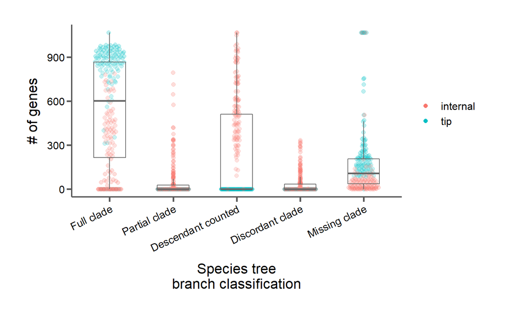

```r
full_clade = select(ps_branches_mf, clade, node.type, num.genes.full)
full_clade$label = "Full clade"
names(full_clade)[3] = "num.genes"

partial_clade = select(ps_branches_mf, clade, node.type, num.genes.partial)
partial_clade$label = "Partial clade"
names(partial_clade)[3] = "num.genes"

descendant_counted = select(ps_branches_mf, clade, node.type, num.genes.descendant.counted)
descendant_counted$label = "Descendant counted"
names(descendant_counted)[3] = "num.genes"

discordant_clade = select(ps_branches_mf, clade, node.type, num.genes.discordant)
discordant_clade$label = "Discordant clade"
names(discordant_clade)[3] = "num.genes"

no_clade = select(ps_branches_mf, clade, node.type, num.genes.missing)
no_clade$label = "Missing clade"
names(no_clade)[3] = "num.genes"
# Subset each clade count column to add a label

clade_counts = rbind(full_clade, partial_clade, descendant_counted, discordant_clade, no_clade)
# Convert branch categories to long format

clade_counts$label = factor(clade_counts$label, levels=c("Full clade", "Partial clade", "Descendant counted", "Discordant clade", "Missing clade"))
# Factorize the labels in order

branch_counts = ggplot(clade_counts, aes(x=label, y=num.genes, group=label, color=node.type)) +
  geom_quasirandom(size=2, width=0.25, alpha=0.25) +
  geom_boxplot(outlier.shape=NA, alpha=0.15, width=0.5, color="#666666") +
  ylab("# of genes") +
  xlab("Species tree\nbranch classification") +
  bartheme() +
  theme(axis.text.x = element_text(angle=25, hjust=1)) +
  guides(colour=guide_legend(override.aes=list(alpha=1)))
print(branch_counts)
```

## 3.2 Tree with OU shift branches labeled

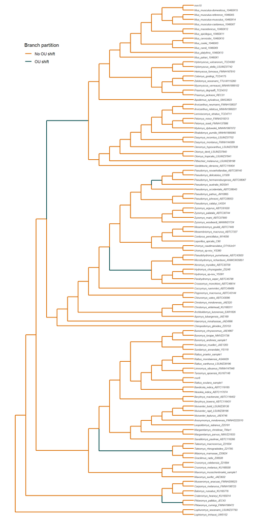

```r
morpho_branches = read.csv(morpho_file, header=F, comment.char="#")
names(morpho_branches) = c("tp")

tree_info$morpho.branch = "No OU shift"
tree_info$morpho.branch[tree_info$tp %in% morpho_branches$tp] = "OU shift"

h = corecol(numcol=1, pal="wilke", offset=3)
l = corecol(numcol=1, offset=3)
# Colors

col_tree = ggtree(tree, size=0.8, ladderize=F, aes(color=tree_info$morpho.branch)) +
  scale_color_manual(name='Branch partition', values=corecol(numcol=2)) +
  xlim(0, xmax) +
  geom_tiplab(color="#333333", fontface='italic', size=2) +
  theme(legend.position=c(0.15,0.9))
print(col_tree)
```

```r
if(save_tree_fig){
  gcf_tree = gcf_tree + geom_text(aes(x=branch, label=ifelse(branch_rates$node.type=="internal",as.character(node), ''), label.size=NA, fill="transparent"), size=2, vjust=-0.2)
  tree_outfile = paste("../../data/trees/", tree_type, "-gcf-tree-PARED-gcf50.pdf", sep="")
  ggsave(tree_outfile, gcf_tree, width=8, height=16, unit="in")
}
# OU shift branch tree
```

## 3.3 Branches under positive selection by OU shift partition

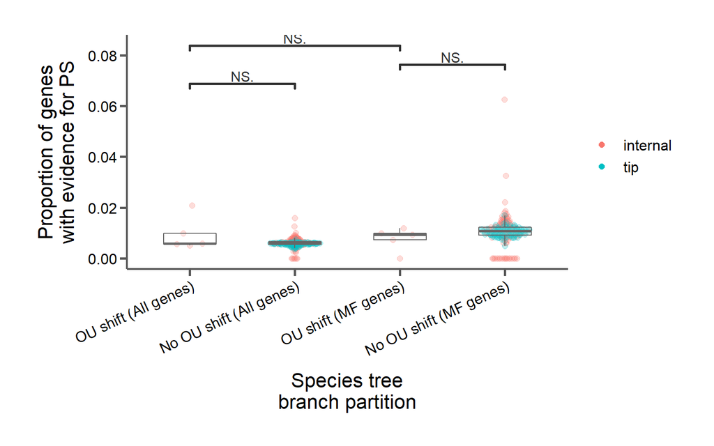

```r
morpho_ps_counts = select(ps_branches_mf, tp, perc.ps.genes)
names(morpho_ps_counts)[2] = "perc.ps.genes.mf"

tree_info = merge(tree_info, morpho_ps_counts, by="tp")

morpho_ps_mf = subset(select(tree_info, clade, node.type, morpho.branch, perc.ps.genes.mf), morpho.branch == "OU shift")
names(morpho_ps_mf)[4] = "perc.ps.genes"
morpho_ps_mf$label = "OU shift (MF genes)"

other_ps_mf = subset(select(tree_info, clade, node.type, morpho.branch, perc.ps.genes.mf), morpho.branch == "No OU shift")
names(other_ps_mf)[4] = "perc.ps.genes"
other_ps_mf$label = "No OU shift (MF genes)"

morpho_ps_all = subset(select(tree_info, clade, node.type, morpho.branch, perc.ps.genes), morpho.branch == "OU shift")
morpho_ps_all$label = "OU shift (All genes)"
#names(full_clade)[3] = "num.genes"

other_ps_all = subset(select(tree_info, clade, node.type, morpho.branch, perc.ps.genes), morpho.branch == "No OU shift")
other_ps_all$label = "No OU shift (All genes)"

ps_df = rbind(morpho_ps_all, other_ps_all, morpho_ps_mf, other_ps_mf)
# Convert branch categories to long format

ps_df$label = factor(ps_df$label, levels=c("OU shift (All genes)", "No OU shift (All genes)", "OU shift (MF genes)", "No OU shift (MF genes)"))

x_comps = list(c("OU shift (All genes)", "No OU shift (All genes)"), c("OU shift (MF genes)", "No OU shift (MF genes)"), c("OU shift (All genes)", "OU shift (MF genes)"))

morpho_branch_ps = ggplot(ps_df, aes(x=label, y=perc.ps.genes, group=label, color=node.type)) +
  geom_quasirandom(size=2, width=0.25, alpha=0.25) +
  geom_boxplot(outlier.shape=NA, alpha=0.15, width=0.5, color="#666666") +
  geom_signif(comparisons=x_comps, map_signif_level=TRUE, textsize=4, size=1, step_increase=0.12, margin_top=0.1, color="#333333") +
  ylab("Proportion of genes\nwith evidence for PS") +
  xlab("Species tree\nbranch partition") +
  bartheme() +
  theme(axis.text.x = element_text(angle=25, hjust=1)) +
  guides(colour=guide_legend(override.aes=list(alpha=1)))
print(morpho_branch_ps)
```

# 4 Positive selection by site

```r
site_ps = read.csv(site_ps_file, header=T, comment.char="#")
site_ps$prop.sites.ps = site_ps$num.sites.ps / site_ps$num.sites
site_ps = site_ps %>% separate(file, c("pid", "aln", "ext"), sep="-", remove=F)

morpho_genes = read.csv(morpho_genes_file, header=F)
names(morpho_genes)[1] = "pid"

arid_genes = read.csv(arid_genes_file, header=F)
names(arid_genes)[1] = "pid"
```

## 4.1 Proportion of sites under selection (all genes)

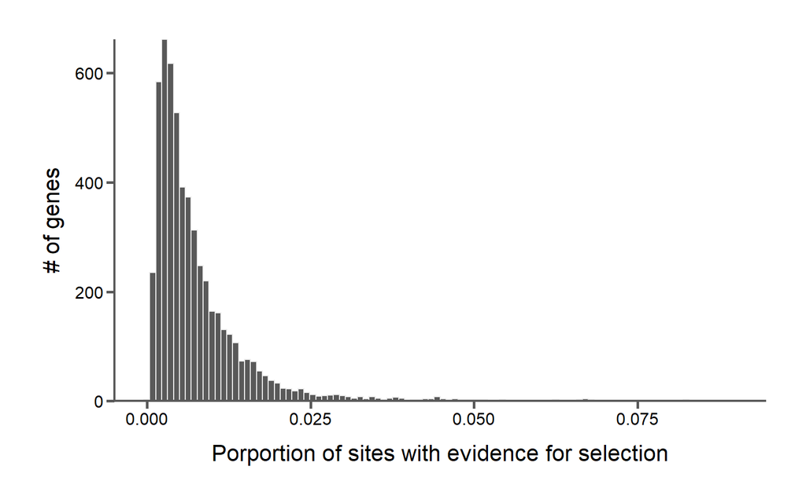

```r
site_ps_counts = ggplot(subset(site_ps, num.sites.ps > 0), aes(x=prop.sites.ps)) +
  geom_histogram(bins=100, color="#ececec") +
  #geom_quasirandom(size=2, width=0.25, alpha=0.25) +
  #geom_boxplot(outlier.shape=NA, alpha=0.15, width=0.5, color="#666666") +
  #geom_signif(comparisons=x_comps, map_signif_level=TRUE, textsize=4, size=1, step_increase=0.12, margin_top=0.1) +
  scale_y_continuous(expand=c(0,0)) +
  ylab("# of genes") +
  xlab("Porportion of sites with evidence for selection") +
  bartheme()
  #theme(axis.text.x = element_text(angle=25, hjust=1)) +
  #guides(colour=guide_legend(override.aes=list(alpha=1)))
print(site_ps_counts)
```

## Proportion of sites under selection (all genes vs. morpho-facial genes vs. arid genes)

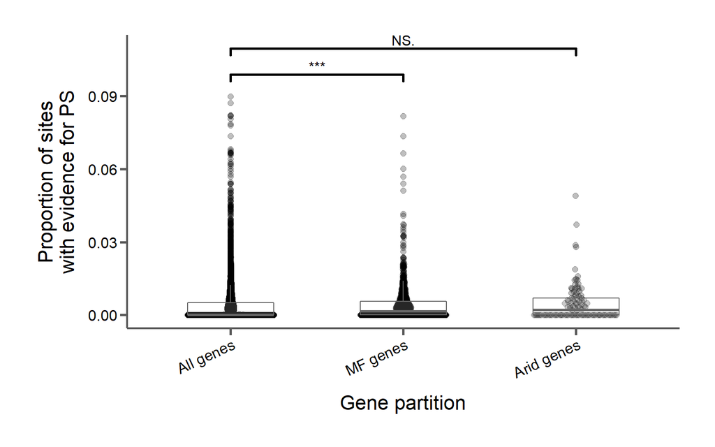

```r
site_ps_mf = subset(site_ps, pid %in% morpho_genes$pid)
site_ps_mf_sub = select(site_ps_mf, pid, prop.sites.ps)
site_ps_mf_sub$label = "MF genes"

site_ps_arid = subset(site_ps, pid %in% arid_genes$pid)
site_ps_arid_sub = select(site_ps_arid, pid, prop.sites.ps)
site_ps_arid_sub$label = "Arid genes"

site_ps_sub = select(site_ps, pid, prop.sites.ps)
site_ps_sub$label = "All genes"

site_ps_cats = rbind(site_ps_sub, site_ps_mf_sub, site_ps_arid_sub)

site_ps_cats$label = factor(site_ps_cats$label, levels=c("All genes", "MF genes", "Arid genes"))

x_comps = list(c("All genes", "MF genes"), c("All genes", "Arid genes"))

site_ps_comps = ggplot(site_ps_cats, aes(x=label, y=prop.sites.ps, group=label)) +
  geom_quasirandom(size=2, width=0.25, alpha=0.25) +
  geom_boxplot(outlier.shape=NA, alpha=0.15, width=0.5, color="#666666") +
  geom_signif(comparisons=x_comps, map_signif_level=TRUE, textsize=4, size=1, step_increase=0.12, margin_top=0.1) +
  ylab("Proportion of sites\nwith evidence for PS") +
  xlab("Gene partition") +
  bartheme() +
  theme(axis.text.x = element_text(angle=25, hjust=1)) +
  guides(colour=guide_legend(override.aes=list(alpha=1)))
print(site_ps_comps)
```

< Back to summary